# Atividade 3 e 4

Jônatha Reis

2023-04-26

#### Nessa atividade transformei o script executado na atividade 3 em uma rotina reprodutível em formato de R Markdown

##### Pacotes necessários

```r
library(tidyverse)
library(rgbif)
library(dplyr)
library(bdc)
library(CoordinateCleaner)
library(ggmap)
library(maps)
library(mapdata)
```

#### Usaremos dados referentes a espécie *Pterois volitans*, popularmente chamado de peixe-leão-vermelho, um peixe venenoso natural dos recifes de coral dos oceanos Índico e Pacífico. Entretanto, vem se espalhando por outras regiões do planeta, como o oceano Atlântico, causando preoucupação a comunidade de cientistas brasileiros. A bioinvasão do *Pterois volitans* pode indiretamente significar a extinção de espécies endêmicas da costa Brasileira, tendo em vista que os indivíduos dessa espécie são caracterizados como excepcionais predadores que podem se alimentar com seu peso a cada dia. Como a fauna local não possui defesa adquirida, a bioivasão do *Pterois volitans* é considerada uma potencial catástrofe ecológica. Levando em consideração o exposto, buscaremos na base de dados Global Biodiversity Information Facility - GBIF, informações sobre os registros de ocorrências do *Pterois volitans* com a finalidade de verificarmos se já existem dados de registros dessa espécie na costa Brasileira.

##### Baixando ocorrências do Pterois volitans.

```r
lionfish_gbif <- occ_data(scientificName = "Pterois volitans",
                      hasCoordinate = TRUE,
                      hasGeospatialIssue=FALSE)
```

##### Baixando ocorrências do Pterois volitans.

```r
# verificando as dimensões do arquivo
dim(lionfish_gbif)
```

[output not shown]

```r
# Checando os campos do arquivo
dim(lionfish_gbif$data)
```

```
## [1] 500 114
```

##### Agora usaremos a função `gbif_issues` na avaliação dos problemas relatados para o conjunto de dados usado nessa atividade.

```r
# checar problemas reportados
issues_gbif <- lionfish_gbif$data$issues %>%
  unique() %>%
  strsplit(., "[,]") %>%
  unlist()

gbif_issues() %>%
  data.frame() %>%
  filter(code %in% issues_gbif)
```

```
##       code                                            issue
## 1      cdc               CONTINENT_DERIVED_FROM_COORDINATES
## 2  cdround                               COORDINATE_ROUNDED
## 3     cudc                 COUNTRY_DERIVED_FROM_COORDINATES
## 4      cum                                 COUNTRY_MISMATCH
## 5   gass84                     GEODETIC_DATUM_ASSUMED_WGS84
## 6   gdativ                           GEODETIC_DATUM_INVALID
## 7   rdativ                            RECORDED_DATE_INVALID
## 8 refuriiv                           REFERENCES_URI_INVALID
## 9    osiic OCCURRENCE_STATUS_INFERRED_FROM_INDIVIDUAL_COUNT
##                                                                                                                                description
## 1                                              The interpreted continent is based on the coordinates, not the verbatim string information.
## 2                                                                                  Original coordinate modified by rounding to 5 decimals.
## 3                                                The interpreted country is based on the coordinates, not the verbatim string information.
## 4                                                           Interpreted country for dwc:country and dwc:countryCode contradict each other.
## 5 Indicating that the interpreted coordinates assume they are based on WGS84 datum as the datum was either not indicated or interpretable.
## 6                                                                                       The geodetic datum given could not be interpreted.
## 7                                                 A (partial) invalid date is given, such as a non existing date, invalid zero month, etc.
## 8                                                                                               An invalid uri is given for dc:references.
## 9                                                                           Occurrence status was inferred from the individual count value
##         type
## 1 occurrence
## 2 occurrence
## 3 occurrence
## 4 occurrence
## 5 occurrence
## 6 occurrence
## 7 occurrence
## 8 occurrence
## 9 occurrence
```

##### Sem nenhum problema sério, vamos filtrar algumas informações necessárias a execução das análises.

```r
lionfish_gbif1 <- lionfish_gbif$data %>%
  dplyr::select(scientificName, acceptedScientificName, decimalLatitude, decimalLongitude,
         issues, waterBody, basisOfRecord, occurrenceStatus, rightsHolder,
         datasetName, recordedBy, depth, locality, habitat)
```

##### Temos 500 ocorrências com 14 variáveis. Aplicaremos a função `distinc` filtrando somente as variáveis que são únicas.

```r
lionfish_gbif1 <- lionfish_gbif1 %>%
  distinct()
```

##### Após a função, ficamos com 444 dados de ocorrência. Para identificar todos os valores únicos presentes nos dados, vamos aplicar a função `unique` a cada coluna com um *loop* na função `lapply`.

```r
lapply(lionfish_gbif1, unique)
```

```
## $scientificName
## [1] "Pterois volitans (Linnaeus, 1758)"
##
## $acceptedScientificName
## [1] "Pterois volitans (Linnaeus, 1758)"
##
## $decimalLatitude
##   [1]  19.357211  18.210600  32.259302 -32.123148  11.834392   6.797184
##   [7] -32.629177  26.257495  20.877156  18.523320  16.745578  -8.681653
##  [13] -27.532258  14.528264   8.101394   4.253618   4.121438  14.527198
##  [19]  14.490562  11.928329   9.191579  20.720860   9.173216  16.385128
##  [25] -16.758687 -32.275904  25.072570  25.899660  18.421720  24.982000
##  [31]  -8.556500  -8.120131 -15.459270 -16.535303  16.805694  21.190954
##  [37] -32.124260  -8.673139  20.819949  12.134015  14.692867  14.687808
##  [43]  16.053238 -19.173152  -8.715310  19.294481  26.294153  19.720250
```

[output cut: 675 more lines]

##### Agora iniciaremos uma avaliação mais minuciosa dos dados, como a validação das coordenadas geográficas usando as funções dos pacotes `CoordinateCleaner` e `bcd`.

```r
# checar coordenadas válidas
check_pf <-
  bdc::bdc_coordinates_outOfRange(
    data = lionfish_gbif1,
    lat = "decimalLatitude",
    lon = "decimalLongitude")
```

```
##
## bdc_coordinates_outOfRange:
## Flagged 0 records.
## One column was added to the database.
```

```r
# checar coordenadas válidas e próximas a capitais (muitas vezes as coordenadas são erroneamente associadas a capitais dos países)

cl <- lionfish_gbif1 %>%
  select(acceptedScientificName, decimalLatitude, decimalLongitude) %>%
  rename(decimallongitude = decimalLongitude,
         decimallatitude = decimalLatitude,
         scientificName = acceptedScientificName) %>%
  as_tibble() %>%
  mutate(val = cc_val(., value = "flagged"),
         sea = cc_sea(., value = "flagged"),
         capital = cc_cap(., value = "flagged"))
```

```
## Testing coordinate validity
```

```
## Flagged 0 records.
```

```
## Testing sea coordinates
```

```
## Testing country capitals
```

```
## Flagged 37 records.
```

##### A visualização desses resultados por uma imagem torna a análise mais compreensivel, além de validarmos os dados e descartamos possíveis ocorrências do peixe-leão em terra.

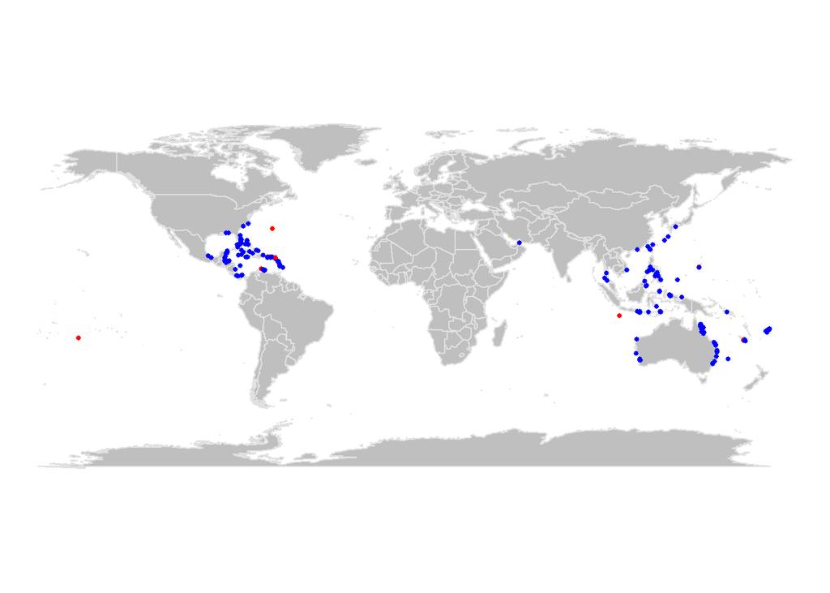

##### Não há coordenadas inválidas, mas checaremos os alertas marcadas em vermelho na imagem. Alguns dos pontos podem aparanter estar em terra, mas a próximidade com regiões insulares pode causar essa falsa impressão visual.

```
## [1] NA                   "Northwest Atlantic"
```

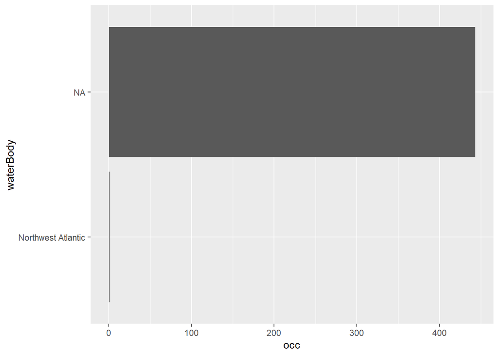

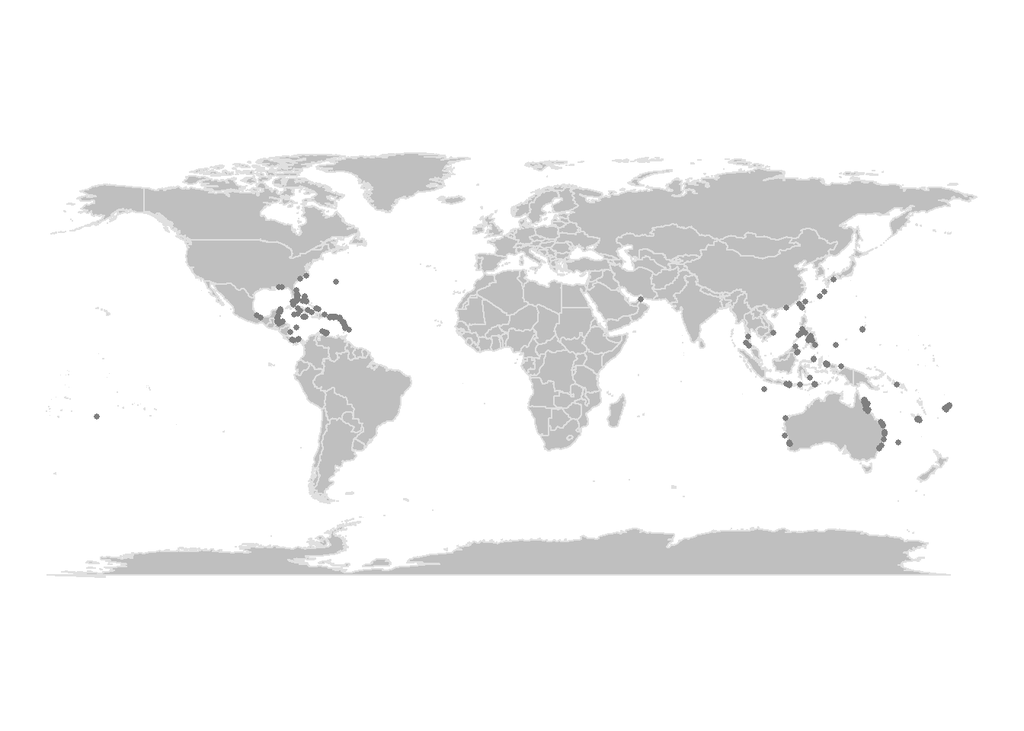

```
## # A tibble: 1 × 1
##   datasetName
##   <chr>
## 1 Puerto Rico Coral Reef Monitoring Program Database Compilation
```

```
## # A tibble: 1 × 14
##   scientificName        acceptedScienti… decimalLatitude decimalLongitude issues
##   <chr>                 <chr>                      <dbl>            <dbl> <chr>
## 1 Pterois volitans (Li… Pterois volitan…            18.2            -67.3 gass8…
## # … with 9 more variables: waterBody <chr>, basisOfRecord <chr>,
## #   occurrenceStatus <chr>, rightsHolder <chr>, datasetName <chr>,
## #   recordedBy <chr>, depth <dbl>, locality <chr>, habitat <chr>
```

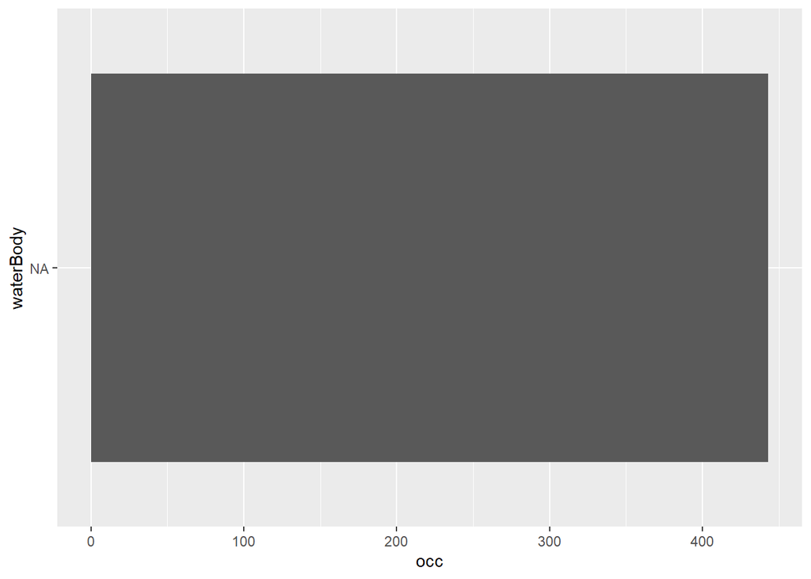

##### Confirmamos que não há nenhum dado de registro ocorrendo em terra. Assim, podemos visualizar novamente o mapa de ocorrências.

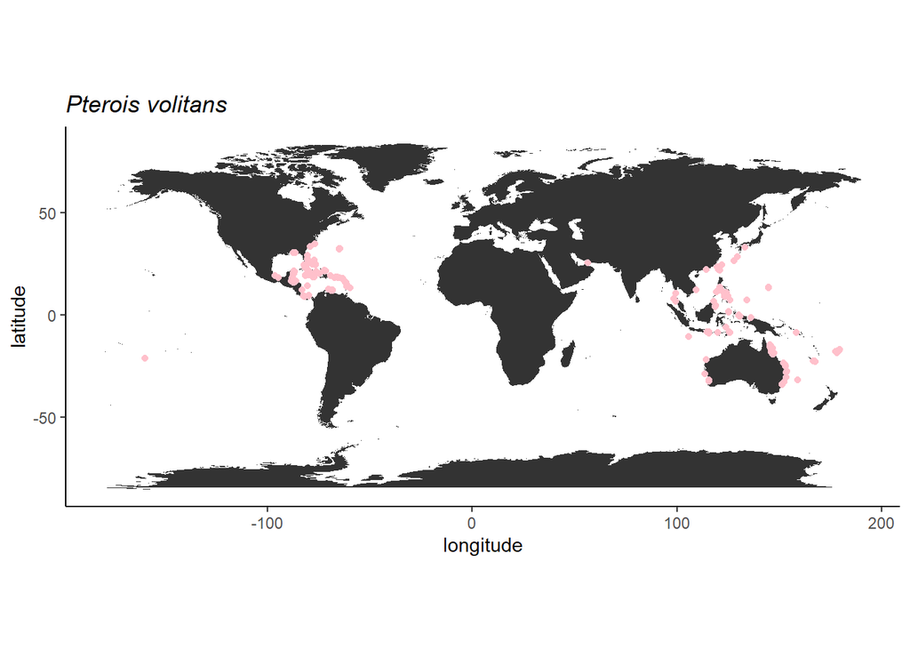

#### Agora faremos os mesmos procedimentos com os dados do OBIS, utilizando o pacote `robis` e a função `occurrence` deste pacote. O banco de dados OBIS é considerado o mais atualizado para animais marinhos.

```
## Retrieved 4656 records of approximately 4656 (100%)
```

##### Checando os dados. Note que estamos realizando os mesmos passos anteriores, mas dessa vez usando os dados de ocorrência do OBIS.

```
##   [1] "infraphylum"
##   [2] "year"
##   [3] "scientificName"
##   [4] "dynamicProperties"
##   [5] "dropped"
##   [6] "gigaclassid"
##   [7] "aphiaID"
##   [8] "language"
##   [9] "decimalLatitude"
##  [10] "subclassid"
##  [11] "type"
##  [12] "gigaclass"
##  [13] "infraphylumid"
##  [14] "phylumid"
##  [15] "familyid"
```

[output cut: 152 more lines]

##### filtrando algumas colunas que serão usadas (as mesmas do GBIF).

##### check problemas reportados (flags)

```
## # A tibble: 9 × 1
##   flags
##   <chr>
## 1 NO_DEPTH
## 2 <NA>
## 3 DATE_IN_FUTURE,NO_DEPTH
## 4 ON_LAND
## 5 DEPTH_EXCEEDS_BATH
## 6 ON_LAND,NO_DEPTH
## 7 NO_DEPTH,ON_LAND
## 8 DEPTH_EXCEEDS_BATH,ON_LAND
## 9 ON_LAND,DEPTH_EXCEEDS_BATH
```

```
## # A tibble: 20 × 1
##    waterBody
##    <chr>
##  1 <NA>
##  2 Asia
##  3 Caribbean
##  4 indien
##  5 Oceania
##  6 Pacifc Ocean
##  7 Pacific
##  8 pacifique
##  9 Africa
## 10 Mar Caribe
## 11 South China Sea
## 12 Bay of Bengal
## 13 Iwayama Bay
## 14 Australia
## 15 Celebes Sea
## 16 Pacific Ocean
## 17 atlantique
## 18 Simpson Harbor
## 19 Karamado Bay
## 20 Gulf of Mexico
```

# Como nossa finalidade é a observação de possíveis ocorrências da espécie fora de seu habitat de origem não realizaremos filtragem com a remoção de registros reportados em regiões distintas do ocenao pacífico e índico.

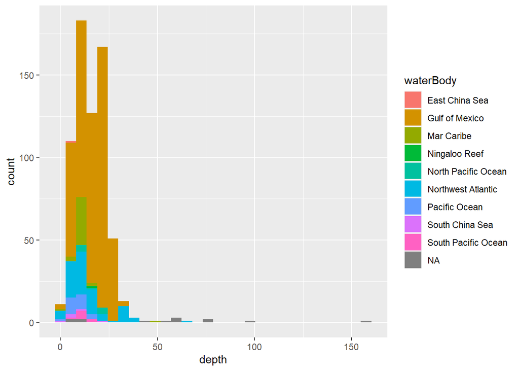

#### Usando a função `flags` (anteriormente) filtramos os dados de ocorrência em terra e removemos os dados sem nome de dataset.

##### Dados filtrados sem as ocorrências errôneas em terra.

##### Visualizando os resultados através de um mapa.

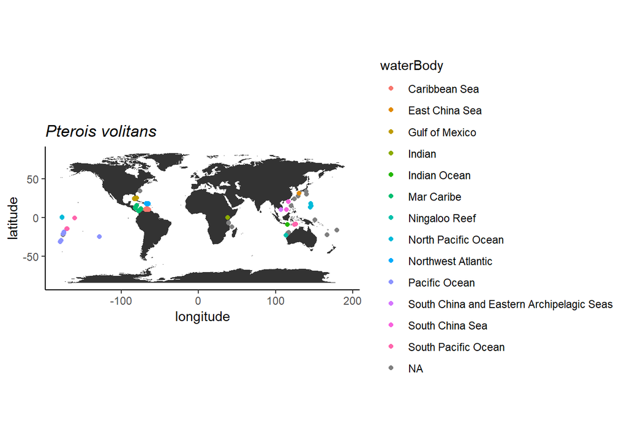

##### Unindo os resultados obtidos com o GBIF e OBIS

```
## [1] "acceptedScientificName" "issues"
```

```
## [1] "acceptedScientificName" "issues"
```

##### Visualizando através de um mapa

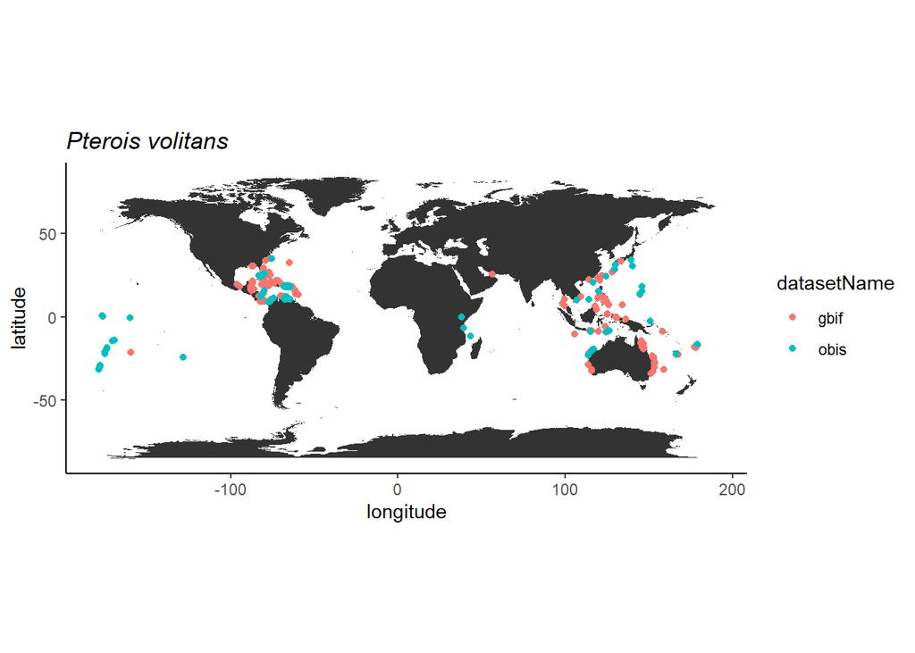